# Aside

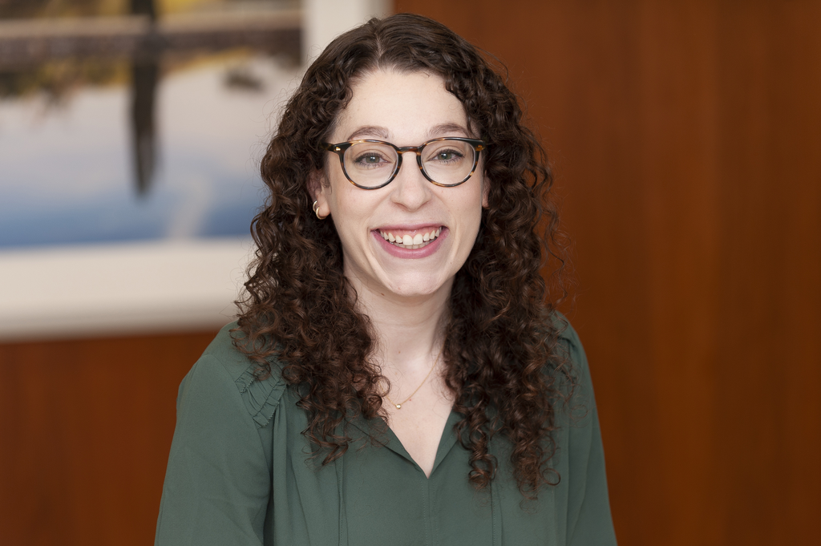

## Contact Info

- hannahlkalvin@gmail.com
- [Google Scholar](https://scholar.google.com/citations?user=Gat1Du8AAAAJ&hl=en)

## Skills

**Expert:** R/RStudio, SAS, Microsoft Office Suite

**Proficient:** Git/GitHub, Joinpoint Regression, Python, SAS-callable SUDAAN, SEER*Stat

**Familiar:** Docker, GIS, LaTeX, Make

## Disclaimer

This resume was made with the R package [**pagedown**](https://github.com/rstudio/pagedown).

Last updated on 2026-04-16.

# Main

## Education

### Emory University

Master of Science in Public Health in Biostatistics

Atlanta, Georgia

2021

*Relevant Coursework:* Survival Analysis Methods, Modern Regression Analysis, Clinical Trials Methodology, Biostatistical Methods, Probability Theory, Applied Linear Models, Statistical Inference, Machine Learning, Statistical Practice, Epidemiology Methods

*Masters Capstone:* “Assessing the Relationship between Breast Cancer Mortality and BMI by State and Race” (Advisor: Jeffrey Switchenko, PhD)

### George Washington University

Bachelor of Science in Public Health, Minor in Biological Sciences *magna cum laude*

Washington, DC

2016

## Professional Experience

### Memorial Sloan Kettering Cancer Center

Research Biostatistician II

New York, New York

Present - 2025

- Collaborate with clinicians and researchers from design to publication phase to answer questions relating to cancer genomics, survival outcomes, etc. using statistical analyses and visualizations
- Perform statistical analysis in SAS and R for Global Cancer Disparities Initiative, Hepato-Pancreatic-Biliary Surgery, and Melanoma groups

### Memorial Sloan Kettering Cancer Center

Research Biostatistician I

New York, New York

2025 - 2022

### Memorial Sloan Kettering Cancer Center

Assistant Research Biostatistician

New York, New York

2022 - 2021

### Emory Rollins School of Public Health

Graduate Research Assistant

Atlanta, Georgia

2021 - 2020

- Researched state/region and race-specific obesity patterns in relation to breast cancer mortality over time
- Compiled and analyze SEER and BRFSS data from 1990-2017 using SAS, SAS-callable SUDAAN, and R
- Produced tables, figures, and maps summarizing obesity and breast cancer mortality rates by state and race
- Analyzed relationship between breast cancer mortality count and BMI by state and race using Poisson Regression

### Emory Biostatistics Collaboration Core

Data Analyst

Atlanta, Georgia

2021 - 2020

- Cleaned Michigan Polybrominated Biphenyls (PBB) Cohort datasets using SAS in order to make data available via a new data management platform
- Created data dictionaries for Michigan PBB Cohort datasets with consistent search term/field label coding
- Conducted power and sample size analyses for NIH grants
- Performed quality assurance checks on psychometric datasets

### Emory Rollins School of Public Health

BIOS 500 Graduate Teaching Assistant

Atlanta, Georgia

2020 - 2020

- Created answer keys and graded assignments and exams for 105 students
- Assisted 105 students in learning SAS programming and statistical methods

### Centers for Disease Control and Prevention

Epidemiology/Data Management Graduate Assistant

Atlanta, Georgia

2020 - 2019

- Analyzed 400,000 observation dataset (National Tuberculosis Surveillance System) and produced SAS summaries
- Composed original research proposal for analytic project based on National Tuberculosis Surveillance System

### WCG Statistics Collaborative (formerly Statistics Collaborative, Inc)

Senior Research Associate, Research Associate, Research Assistant

Washington, DC

2019 - 2016

- Coordinated and supported several Phase 2 and Phase 3 clinical trials with indications for: heart failure, cardiovascular disease, chronic kidney disease, pediatric growth hormone treatment, and HIV
- Managed and led multiple projects under supervision of Statistical Scientists for: orphan neurological disorders, infectious disease, and cardiovascular disease in a genetically pre-specified population
- Wrote and reviewed data monitoring committee reports
- Prepared table, figure, and listing shells for statistical analysis plans
- Utilized standard SAS code and in-house macros to produce and audit graphs, tables, and listings
- Created and audited SAS analysis programs

## Presentations and Posters

Expanding biostatistics research and training efforts beyond MSK - A global health initiative

Memorial Sloan Kettering Department of Epidemiology and Biostatistics Seminar Series

2025

Linear Regression II: Regression Diagnostics

Biostatistics Virtual Lecture for Obafemi Awolowo University, Ile Ife, Nigeria

2024

Linear Regression I: Introduction and Assumptions

Biostatistics Virtual Lecture for Obafemi Awolowo University, Ile Ife, Nigeria

2024

Real-world evidence following a clinical trial: An application in biliary tract cancer

Society for Clinical Trials Annual Meeting in Boston, MA

2024

## Publications

Please see [Google Scholar](https://scholar.google.com/citations?user=Gat1Du8AAAAJ&hl=en) for a complete list of publications.

Mastectomy for Breast Cancer in Nigeria: A Mixed-Methods Study of Barriers, Facilitators, and Patient Attitudes

Psycho-Oncology

2026

Anya Romanoff, Olalekan Olasehinde, Kathleen Lynch, Olayide Agodirin, Chukwuma Eze Okereke, Akintayo Taiwo Olaniyan, Adeoluwa Oluwaseyi Adeleye, Hannah L Kalvin, Alexia Iasonos, Israel Adeyemi Owoade, Rivka Kahn, Thomas Amburn, Grace Fitzgerald, Ryan Fodero, Rebecca Promise Akinmaye, Mercy Awe, Saheed Lawal, Oyindamola Adeleye, Funmilola Wuraola, Adewale Aderounmu, Adewale Adisa, William E. Rosa, Benjamin O. Anderson, Victoria L. Mango, T. Peter Kingham, Olusegun Isaac Alatise

Outcomes of Patients Undergoing Sentinel Lymph Node Biopsy for Merkel Cell Carcinoma

Annals of Surgical Oncology

2025

Edmund K Bartlett, Hannah L Kalvin, Christopher A Barker, Charlotte E Ariyan, Mary Sue Brady, Danielle M Bello, Ciara M Kelly, Joyce M Chen, Klaus J Busam, Katherine S Panageas, Daniel G Coit

Local Recurrence Following Complete Surgical Excision of Primary Merkel Cell Carcinoma

Annals of Surgical Oncology

2025

Fergal G Kavanagh, Hannah L Kalvin, Edmund K Bartlett, Christopher A Barker, Charlotte E Ariyan, Mary S Brady, Danielle M Bello, Klaus J Busam, Katherine S Panageas, Daniel G Coit

One-year mortality after hepatectomy: defining a novel quality metric

Annals of Surgical Oncology

2025

Lily V Saadat, Debra A Goldman, Hannah Kalvin, Mithat Gonen, Kevin C Soares, Alice C Wei, Vinod P Balachandran, T Peter Kingham, Jeffrey Drebin, William R Jarnagin, Michael I D’Angelica

Impact of financial toxicity on treatment adherence and quality of life in pancreatic cancer

JCO Oncology Practice

2025

Lauren E Schleimer, Emeline Aviki, Hannah L Kalvin, Josephine Magnin, Stefania S Sokolowski, T Peter Kingham, Eileen M O’Reilly, Anna M Varghese, Kevin C Soares, Jeffrey Drebin, Michael I D’Angelica, William R Jarnagin, Mithat Gonen, Bridgette Thom, Alice C Wei

Management and Outcomes of Clostridioides difficile Infection in Patients on Immune Checkpoint Inhibitors

Journal of the National Comprehensive Cancer Network

2025

Patrick T Magahis, Deepika Satish, Mini Kamboj, Ngolela Esther Babady, Jennele Baul, Hannah L Kalvin, Katherine Panageas, Michael A Postow, Monika Laszkowska, David M Faleck

Robotic Versus Open Placement of Hepatic Artery Infusion Pumps

Annals of Surgical Oncology

2025

Lauren E Schleimer, Annie Liu, Hannah L Kalvin, Ahmad Bashir Barekzai, Ankur P Choubey, Joslyn Jung, Rubiya Haque, William R Jarnagin, Vinod P Balachandran, Ruben Geevarghese, Brett Marinelli, Mithat Gonen, Jeffrey Drebin, Peter J Allen, Michael I D’Angelica, Alice C Wei, Sabino Zani, T Peter Kingham, Michael E Lidsky, Kevin C Soares

Health Care Professional Adherence to Breast Cancer Management Guidelines in Nigeria

JAMA Network Open

2025

Anya Romanoff, Olalekan Olasehinde, Kathleen Lynch, Sharif Folorunso, Oluwatosin Omoyiola, Betiku Omolade, Adeleye Omisore, Chukwuma Eze Okereke, Olayide Agodirin, Abubakar Bala Muhammad, Nuhu Ali, Omorodion Irowa, Nneka Sunday Nweke, Uchechukwu Emmanuel Nwokwu, Adewale Aderounmu, Funmilola Wuraola, Hannah L Kalvin, Rivka Kahn, Grace Fitzgerald, Cristina Olcese, Alexia Iasonos, Victoria L Mango, Jamie S Ostroff, Rachel Vreeman, Benjamin O Anderson, T Peter Kingham, Olusegun Isaac Alatise

Analysis of Risk Factors, Treatment Patterns, and Survival Outcomes After Emergency Presentation With Colorectal Cancer: A Prospective Multicenter Cohort Study in Nigeria

Journal of Surgical Oncology

2025

Adeniyi S Aderibigbe, Anna J Dare, Hannah L Kalvin, Olalekan Olasehinde, Funmilola Wuraola, Adewale Adisa, Adeleye Dorcas Omisore, Akinwumi O Komolafe, Oluwatosin Zainab Omoyiola, Chukwuma Eze Okereke, Aba Katung, Adedeji Egberoungbe, Olufemi Ariyibi, Samuel Adegboyega Olatoke, Ademola Adetoyese Adeyeye, Sulaiman Olayide Agodirin, Matthew Olumuyiwa Bojuwoye, James Oluwaleke Fayenuwo, Oluwabusayomi Roseline Ademakinwa, Dapo Osinowo, Abdul‐Razak Lawal, Fatimah B Abdulkareem, Debra Goldman, Gregory Knapp, Shilpa Murthy, Rivka Kahn, Mithat Gonen, T Peter Kingham, Olusegun I Alatise, African Research Group in Oncology Colorectal Cancer Working Group

Intracranial Outcomes of Ipilimumab and Nivolumab in Melanoma Brain Metastases After Progression on Anti–PD-1 Therapy

JAMA Oncology

2025

Sarah E Lochrin, Hannah L Kalvin, James W Smithy, Monica F Chen, Parisa Momtaz, Alexander N Shoushtari, Katherine S Panageas, Michael A Postow

Leveraging a Patient-Derived Tumoroid Platform for Precision Radiotherapy: Uncovering DNA Damage Repair Inhibitor-Mediated Radiosensitization and Therapeutic Resistance in Rectal Cancer

medRxiv

2025

W Zambare, H Huang, C Wu, S Yoder, Y Gao, J Kim,H Kalvin, M Del Latto, A Garcia, S Meguro, P Bleu, MJ Kim, M Fiasconaro, A Bercz, A Kim, MR Weiser, E Pappou, A Cercek, K Ganesh, PB Paty, J Garcia-Aguilar, M Gonen, X Chen, JJ Smith, PB Romesser

Abstract also presented at AACR Special Conference in Cancer Research: Translating Targeted Therapies in Combination with Radiotherapy

Virtual Biostats Day: An Interactive Online Biostatistics Outreach Program Directed at High School Students in Groups Historically Underrepresented in STEM Careers

Journal of Statistics and Data Science Education

2025

Esther Drill, Jessica A Lavery, Stephanie Lobaugh, Jessica Flynn, Samantha Brown, Hannah Kalvin, Joanne F Chou, David Nemirovsky, Zoe Guan, Sujata Patil, Kay See Tan

KRAS Variants Are Associated With Survival Outcomes and Genomic Alterations in Biliary Tract Cancers

JCO Precision Oncology

2024

Rebecca Gelfer, Aiste Gulla, Hannah L Kalvin, Yi Song, James Harding, Ghassan K Abou-Alfa, Eileen M O’Reilly, Wungki Park, Rohit Chandwani, Alice Wei, Peter Kingham, Jeffrey Drebin, Vinod Balachandran, Michael D’Angelica, Kevin Soares, Mithat Gonen, William R Jarnagin

Has Management of Intrahepatic Cholangiocarcinoma Evolved with the Evidence? Trends and Practice Patterns from the National Cancer Database

Annals of Surgical Oncology

2024

Lauren E Schleimer, Hannah L Kalvin, Ryan J Ellis, T Peter Kingham, Kevin C Soares, Michael I D’Angelica, Vinod P Balachandran, Jeffrey Drebin, Andrea Cercek, Ghassan K Abou-Alfa, Eileen M O’Reilly, James J Harding, Mithat Gönen, Alice C Wei, William R Jarnagin

Interference with activities of daily living according to pain level after breast surgery

Surgical Oncology Insight

2024

Kate R Pawloski, Su Hnin, Hannah L Kalvin, Varadan Sevilimedu, Tiana Le, Audree B Tadros, Laurie J Kirstein, Monica Morrow, Tracy-Ann Moo

Early on-treatment assessment of T-cells, cytokines and tumor DNA with adaptively-dosed nivolumab+ ipilimumab: final results from the phase 2 ADAPT-IT study

Clinical Cancer Research

2024

James W Smithy, Hannah L Kalvin, Fiona D Ehrich, Ronak Shah, Matthew Adamow, Vladislav Raber, Colleen A Maher, Jenna Kleman, Debra AG McIntyre, Alexander N Shoushtari, Allison Betof Warner, Margaret K Callahan, Parisa Momtaz, Omar Eton, Suresh Nair, Jedd D Wolchok, Paul B Chapman, Michael F Berger, Katherine S Panageas, Michael A Postow

Content presented at American Society of Clinical Oncology 2023 Annual Meeting

Outcomes of Combination Platinum-Doublet Chemotherapy and Anti-PD(L)-1 Blockade in KRASG12C-Mutant Non-Small Cell Lung Cancer

The Oncologist

2023

Arielle Elkrief, Biagio Ricciuti, Joao V Alessi, Teng Fei, Hannah L Kalvin, Jacklynn V Egger, Hira Rizvi, Rohit Thummalapalli, Giuseppe Lamberti, Andrew Plodkowski, Matthew D Hellmann, Mark G Kris, Maria E Arcila, Marina K Baine, Charles M Rudin, Piro Lito, Marc Ladanyi, Adam J Schoenfeld, Gregory J Riely, Mark M Awad, Kathryn C Arbour

Recurring Pancreatic Neuroendocrine Tumor: timing and pattern of recurrence, and current treatment

Annals of Surgery

2023

Pulvirenti A, Javed AA, Michelakos T, Sekigami Y, Zheng J, Kalvin HL, McIntyre CA, Nebbia M, Chou JF, Gonen M, Ra N, Reidy-Lagunes DL, Zureikat AH, Ferrone CR, He J, Wei AC

Presented at 2022 International Hepato-Pancreato-Biliary Association World Congress

Beyond the Five-Year Milestone: Long-term Survivorship of Melanoma Patients Treated Off-Trial with anti-PD-1

Pigment Cell & Melanoma Research

2023

Loo K, Kalvin HL, Panageas KS, Callahan MK, Chapman PB, Momtaz P, Shoushtari A, Wolchok JD, Postow MA, Betof Warner A,

Long-term Outcomes After Initial Disease Progression with Anti-PD-1 in Melanoma

American Society of Clinical Oncology Abstract Forum for Medical Students & Residents

2022

Loo K, Park BC, Kalvin HL, Panageas KS, Johnson DB, Warner AB

Melanoma-Specific Clinical Outcomes of Inpatient Immune Checkpoint Blockade Treatment

The Oncologist

2022

Loo K, Kalvin HL, Panageas KS, Park V, Postow MA

How Much Pain Will I Have After Surgery? A Preoperative Nomogram to Predict Acute Pain Following Mastectomy

Annals of Surgical Oncology

2022

Pak LM, Pawloski KR, Sevilimedu V, Kalvin HL, Le T, Tokita HK, Tadros A, Morrow M, Van Zee KJ, Kirstein LJ, Moo TA

Also presented at Society of Surgical Oncology 2022 Annual Meeting

## Leadership & Service

### Society for Clinical Trials

Program Committee Member (2025-present), Member (2023-present)

N/A

Present - 2023

- Review and select applications for sessions at annual meeting
- Ensure sessions represent diverse interests
- Select session moderators
- Choose poster award recipients

### Cycle for Survival

Team Captain (2025-present), Member (2021-present)

N/A

Present - 2021

- Lead fundraising efforts for department team

### [Memorial Sloan Kettering Bridge to Biostats Committee](https://www.mskcc.org/departments/epidemiology-biostatistics/bridge-biostats)

Member

N/A

Present - 2021

*Mission: Foster a more inclusive biostats community by creating programs to increase awareness of and interest in the field of Biostatistics among New York City public high school students.*

- Co-lead 8th grade and high school “Biostats Days” to introduce students to biostatistics
- Mentor for high school student as part of the Summer Exposure Program in collaboration with Memorial Sloan Kettering’s Office of Diversity Programs
- Teach introduction to R Studio for high school students in the Summer Exposure Program